# kenya_code

Dianovics Dominik

2023-12-15

# Final project using Kenya census 2019

[Github tidytuesday link](https://github.com/rfordatascience/tidytuesday/blob/master/data/2021/2021-01-19/readme.md)

## Firstly, **import** the data

```r
data <- tt_load('2021-01-19')

gender <- data$gender
crops <- data$crops
households <- data$households
```

## Then data **cleaning**

```r
#Issue with crops, all names are caps lock
crops <- crops |>
  mutate(
    SubCounty = str_to_lower(SubCounty),
    SubCounty = str_to_title(SubCounty)
  )

#Removed the Khat crop because I don't know what that is and there are too many missing values
crops <- crops[, !colnames(crops) %in% "Khat (Miraa)"]


#Issue with city naming, not consistent through datasets
crops <- crops |>
  mutate(
    County = SubCounty,
  ) |>
  dplyr::select(-SubCounty)

#Changing the naming from Total to Kenya
gender <- gender |>
  mutate(
    County = ifelse(County == "Total", "Kenya", County)
  )

#Cleaning whitespaces
gender$County <- gsub(" ", "", gender$County)
households$County <- trimws(households$County)
```

```r
#Function that tries to match the County names to each other by stringdist
find_best_match <- function(county, reference_counties) {
  distances <- stringdistmatrix(county, reference_counties)
  best_match_index <- which.min(distances)
  best_match <- reference_counties[best_match_index]
  return(best_match)
}

#Function had an issue with only one value, the Nairobi city, probably due to two words in the name
crops$County[crops$County == "Nairobi"] <- "Nairobi City"
crops$best_match <- sapply(crops$County, find_best_match, reference_counties = gender$County)
households$best_match <- sapply(households$County, find_best_match, reference_counties = gender$County)

#Merge datasets
merged_dataset <- left_join(crops, households, by = c("best_match" = "County")) |>
  left_join(gender, by = c("best_match" = "County"))

# Clean up
merged_dataset <- merged_dataset |>
  dplyr::select(-best_match, -best_match.y)

#County in the first column
merged_dataset <- merged_dataset |>
  dplyr::select(County, everything())
```

# Data exploration

## **Gender**

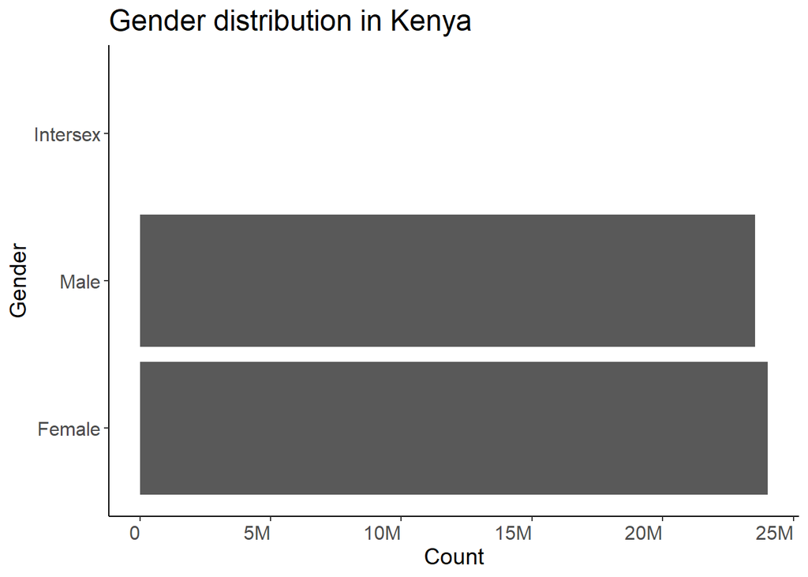

```r
#Gender in the whole of Kenya
data_kenya <- filter(merged_dataset, County == "Kenya")
data_kenya_long <- pivot_longer(data_kenya, cols = c("Male", "Female", "Intersex"), names_to = "Gender", values_to = "Count")
data_kenya_long |>
  ggplot(aes(x = reorder(Gender, -Count), y = Count)) +
  geom_col() +
  scale_y_continuous(labels = scales::label_number_si()) +
  coord_flip() +
  theme_classic() +
  labs(
    y = "Count",
    x = "Gender"
  ) +
  ggtitle("Gender distribution in Kenya") +
  theme(
    axis.text.x = element_text(size = 12, family = "Times", hjust = 1),
    axis.text.y = element_text(size = 12, family = "Times"),
    plot.title = element_text(size = 18, family = "Times"),
    axis.title = element_text(size = 14, family = "Times")
  )
```

## **Farming production**

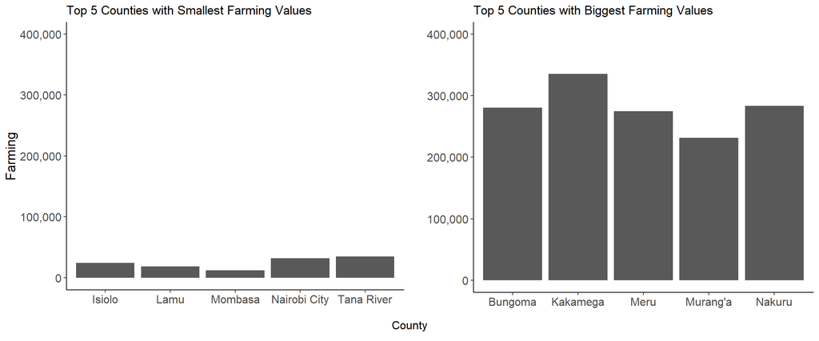

```r
#Farming production in the 5 biggest and smallest counties by production
smallest_producers <- merged_dataset |>
  arrange(Farming) |>
  slice_head(n = 5) |>
  ggplot(aes(x = County, y = Farming)) +
  geom_col() +
  theme_classic() +
  labs(title = "Top 5 Counties with Smallest Farming Values",
       x = "",
       y = "Farming") +
  scale_y_continuous(labels = comma, limits = c(0,400000)) +
  theme(
    axis.text.x = element_text(size = 12),
    axis.text.y = element_text(size = 12),
    axis.title = element_text(size = 14)
  )

biggest_producers <- merged_dataset |>
  filter(County != "Kenya") |>
  arrange(desc(Farming)) |>
  slice_head(n = 5) |>
  ggplot(aes(x = County, y = Farming)) +
  geom_col() +
  theme_classic() +
  labs(title = "Top 5 Counties with Biggest Farming Values",
       x = "",
       y = "") +
  scale_y_continuous(labels = comma, limits = c(0,400000)) +
  theme(
    axis.text.x = element_text(size = 12),
    axis.text.y = element_text(size = 12)
  )


grid.arrange(smallest_producers, biggest_producers, ncol = 2, bottom = textGrob("County", vjust = -0.5))
```

## **Population**

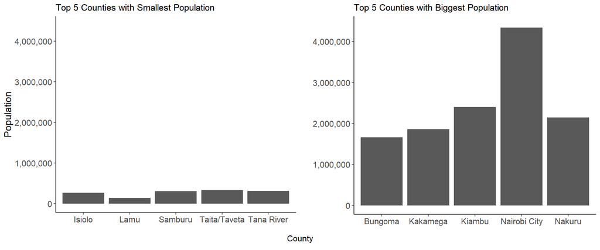

```r
#Population in the 5 biggest and smalles counties
smallest_population <- merged_dataset |>
  arrange(Population) |>
  slice_head(n = 5) |>
  ggplot(aes(x = County, y = Population)) +
  geom_col() +
  theme_classic() +
  labs(title = "Top 5 Counties with Smallest Population",
       x = "",
       y = "Population") +
  scale_y_continuous(labels = comma, limits = c(0,4400000)) +
  theme(
    axis.text.x = element_text(size = 12),
    axis.text.y = element_text(size = 12),
    axis.title = element_text(size = 14)
  )



biggest_population <- merged_dataset |>
  filter(County != "Kenya") |>
  arrange(desc(Population)) |>
  slice_head(n = 5) |>
  ggplot(aes(x = County, y = Population)) +
  geom_col() +
  theme_classic() +
  labs(title = "Top 5 Counties with Biggest Population",
       x = "",
       y = "") +
  scale_y_continuous(labels = comma, limits = c(0,4400000)) +
  theme(
    axis.text.x = element_text(size = 12),
    axis.text.y = element_text(size = 12)
  )

grid.arrange(smallest_population, biggest_population, ncol = 2, bottom = textGrob("County", vjust = -0.5))
```

# Descriptives

## **Means**

```r
merged_dataset %>%
  summarise(
    Population = mean(Population),
    Farming = mean(Farming),
    "N of households" = mean(NumberOfHouseholds)
  ) %>%
  pivot_longer(everything(), names_to = "Variable", values_to = "Mean") %>%
  mutate(
    Mean = round(Mean, 0)
  ) |>
  gt() %>%
  tab_header(
    title = md("**Descriptive statistics**"),
    subtitle = "Kenya census 2019"
  ) %>%
  fmt_number(
    columns = vars(Variable)
  )
```

**Descriptive statistics**

Kenya census 2019

| Variable | Mean |
| --- | --- |
| Population | 1967220 |
| Farming | 264759 |
| N of households | 505996 |

## **Standard deviation**

```r
merged_dataset |>
  summarise(
    Population = sd(Population),
    Farming = sd(Farming),
    "N of households" = sd(NumberOfHouseholds)
  ) |>
  pivot_longer(everything(), names_to = "Variable", values_to = "SD") |>
  mutate(
    SD = round(SD, 0)
  ) |>
  gt() |>
  tab_header(
    title = md("**Descriptive statistics**"),
    subtitle = "Kenya census 2019"
  ) |>
  fmt_number(
    columns = c(Variable)
  )
```

**Descriptive statistics**

Kenya census 2019

| Variable | SD |
| --- | --- |
| Population | 6704047 |
| Farming | 900960 |
| N of households | 1731138 |

## **Outliers**

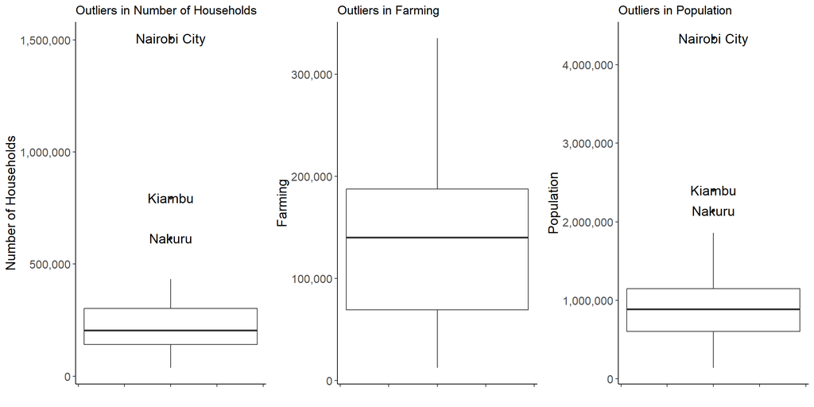

```r
##Population
outlier_population <- merged_dataset |>
  filter(County != "Kenya") |>
  ggplot(aes(x = 1, y = Population)) +
  geom_boxplot() +
  geom_text(aes(label = ifelse(Population < quantile(Population, 0.25) - 1.5 * IQR(Population) |
                                  Population > quantile(Population, 0.75) + 1.5 * IQR(Population), County, "")),
            size = 5) +
  theme_classic() +
  scale_y_continuous(labels = comma) +
  labs(
    title = "Outliers in Population",
    x = "",
    y = "Population"
  ) +
  theme(axis.text.x = element_blank(),
        axis.text.y = element_text(size = 12),
        axis.title = element_text(size = 14)
        )

##Farming
outlier_farming <- merged_dataset |>
  filter(County != "Kenya") |>
  ggplot(aes(x = 1, y = Farming)) +
  geom_boxplot() +
  geom_text(aes(label = ifelse(Farming < quantile(Farming, 0.25) - 1.5 * IQR(Farming) |
                                  Farming > quantile(Farming, 0.75) + 1.5 * IQR(Farming), County, "")),
            size = 5) +
  theme_classic() +
  scale_y_continuous(labels = comma) +
  labs(
    title = "Outliers in Farming",
    x = "",
    y = "Farming"
  ) +
  theme(axis.text.x = element_blank(),
        axis.text.y = element_text(size = 12),
        axis.title = element_text(size = 14)
        )

##Households
outlier_household <- merged_dataset |>
  filter(County != "Kenya") |>
  ggplot(aes(x = 1, y = NumberOfHouseholds)) +
  geom_boxplot() +
  geom_text(aes(label = ifelse(NumberOfHouseholds < quantile(NumberOfHouseholds, 0.25) - 1.5 * IQR(NumberOfHouseholds) |
                                  NumberOfHouseholds > quantile(NumberOfHouseholds, 0.75) + 1.5 * IQR(NumberOfHouseholds), County, "")),
            size = 5) +
  theme_classic() +
  scale_y_continuous(labels = comma) +
  labs(
    title = "Outliers in Number of Households",
    x = "",
    y = "Number of Households"
  ) +
  theme(axis.text.x = element_blank(),
        axis.text.y = element_text(size = 12),
        axis.title = element_text(size = 14)
        )

#Conclusion: Even though there are three outliers, I will not remove them because they represent a natural occurence, where people congregate in urban areas, and the outliers are the biggest cities in Kenya.

grid.arrange(outlier_household, outlier_farming, outlier_population, ncol = 3)
```

#### Conclusion: Even though there are three outliers, I will not remove them because they represent a natural occurence, where people congregate in urban areas, and the outliers are the biggest cities in Kenya.

## **Plant production distribution**

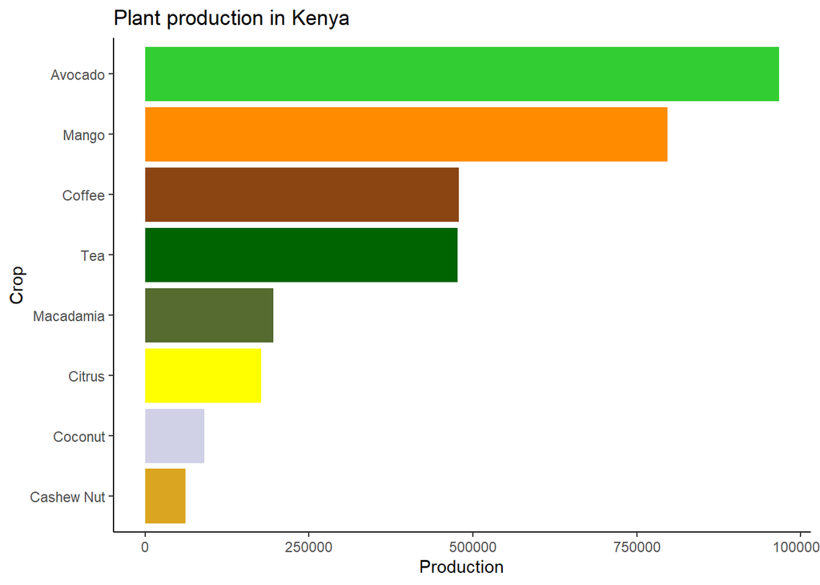

```r
#Create color coding
plants <- c("Tea", "Coffee", "Avocado", "Citrus", "Mango", "Coconut", "Macadamia", "Cashew Nut")
plant_colors <- c(
  Tea = "darkgreen",
  Coffee = "saddlebrown",
  Avocado = "limegreen",
  Citrus = "yellow",
  Mango = "darkorange",
  Coconut = "#d0d1e6",
  Macadamia = "darkolivegreen",
  "Cashew Nut" = "goldenrod"
)

#Create plot
merged_dataset |>
  filter(County == "Kenya") |>
  pivot_longer(cols = plants, names_to = "Crop", values_to = "Production") |>
  ggplot(aes(x = fct_reorder(Crop, Production), y = Production)) +
  geom_bar(stat = "identity", fill = plant_colors) +
  coord_flip() +
  theme_classic() +
  labs(
    title = "Plant production in Kenya",
    x = "Crop",
    y = "Production"
  )
```

# Hypotheses

## 1. **Linear regression**

- H1: Does the *population* affect the *farming production*?
- H2: Is there a positive correlation between *Tea* and *Coffee* production?

## 2. **Mediation**

### **Hypothesis** 1.a: Linear regression

```r
#Does the population affect the farming production?

#Delete Kenya
counties_data <- merged_dataset |>
  filter(County != "Kenya")

#Check if they correlate
cor(counties_data$Population, counties_data$Farming)
```

```
## [1] 0.3836631
```

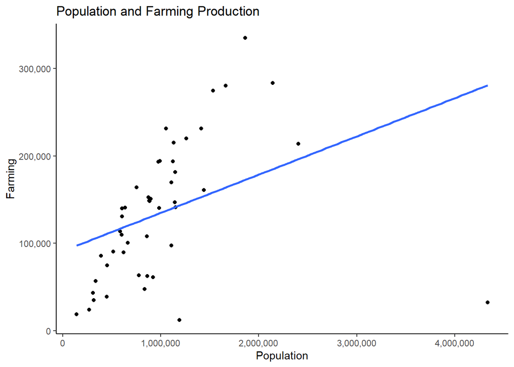

```r
#Create plot
counties_data |>
  ggplot(aes(x = Population, y = Farming)) +
  geom_point() +
  geom_smooth(method = "lm", se = FALSE) +
  labs(
    title = "Population and Farming Production",
    x = "Population",
    y = "Farming"
  ) +
  theme_classic() +
  scale_y_continuous(labels = comma) +
  scale_x_continuous(labels = comma)
```

```r
#Assumption 1.1: Normality
shapiro.test(counties_data$Population)
```

```
##
##  Shapiro-Wilk normality test
##
## data:  counties_data$Population
## W = 0.76621, p-value = 0.0000003004
```

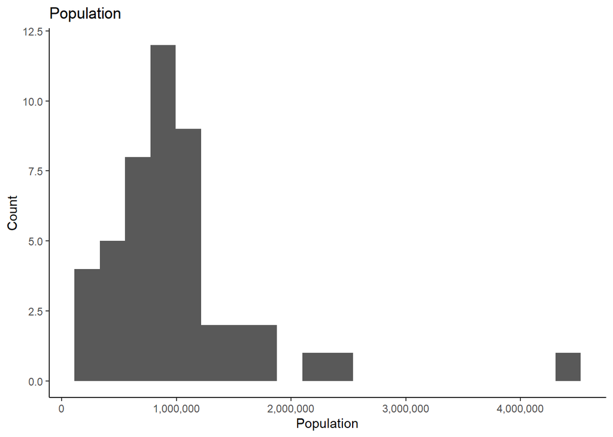

```r
counties_data |>
  ggplot(aes(x = Population)) +
  geom_histogram(bins = 20) +
  labs(
    title = "Population",
    x = "Population",
    y = "Count"
  ) +
  theme_classic() +
  scale_y_continuous(labels = comma) +
  scale_x_continuous(labels = comma)
```

```r
shapiro.test(counties_data$Farming)
```

```
##
##  Shapiro-Wilk normality test
##
## data:  counties_data$Farming
## W = 0.96723, p-value = 0.2073
```

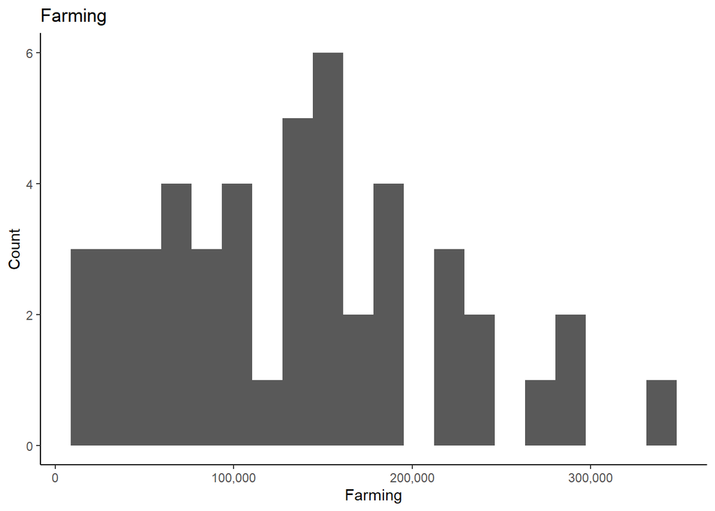

```r
counties_data |>
  ggplot(aes(x = Farming)) +
  geom_histogram(bins = 20) +
  labs(
    title = "Farming",
    x = "Farming",
    y = "Count"
  ) +
  theme_classic() +
  scale_y_continuous(labels = comma) +
  scale_x_continuous(labels = comma)
```

```r
##Nairobi significantly alters the normality

pop_farming <- lm(Farming ~ Population, data = counties_data)

#Assumption 1.2: Linearity
raintest(pop_farming)
```

```
##
##  Rainbow test
##
## data:  pop_farming
## Rain = 4.9462, df1 = 24, df2 = 21, p-value = 0.0002283
```

```r
##Shows nonlinearity

#Assumption 1.3: Homoscedasticity
bptest(pop_farming)
```

```
##
##  studentized Breusch-Pagan test
##
## data:  pop_farming
## BP = 27.443, df = 1, p-value = 0.0000001618
```

```r
##Shows heteroscedasticity

#Assumption 1.4: Normality of residuals
shapiro.test(pop_farming$residuals)
```

```
##
##  Shapiro-Wilk normality test
##
## data:  pop_farming$residuals
## W = 0.96207, p-value = 0.13
```

```r
##Normality of residuals met

#Summary of model
glance(pop_farming)
```

```
## # A tibble: 1 × 12
##   r.squared adj.r.squared  sigma statistic p.value    df logLik   AIC   BIC
##       <dbl>         <dbl>  <dbl>     <dbl>   <dbl> <dbl>  <dbl> <dbl> <dbl>
## 1     0.147         0.128 72960.      7.77 0.00776     1  -592. 1190. 1195.
## # ℹ 3 more variables: deviance <dbl>, df.residual <int>, nobs <int>
```

#### Overall the model does not work with Nairobi in it, so I will remove it and see if it works without it. There is no normality and no homoscedasticity.

### **Hypothesis** 1.b: Linear regression without Nairobi

```r
#Assumption 2.1: Normality
counties_data_no_capital <- counties_data |>
  filter(County != "Nairobi City")
shapiro.test(counties_data_no_capital$Population)
```

```
##
##  Shapiro-Wilk normality test
##
## data:  counties_data_no_capital$Population
## W = 0.94095, p-value = 0.02124
```

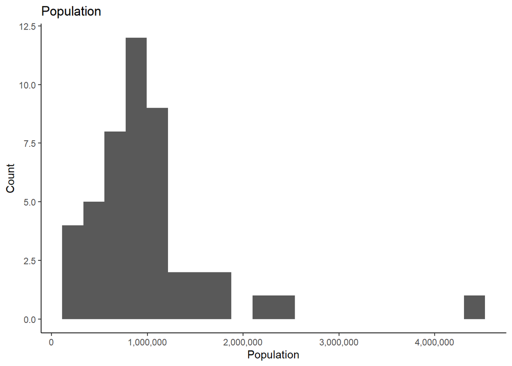

```r
counties_data |>
  ggplot(aes(x = Population)) +
  geom_histogram(bins = 20) +
  labs(
    title = "Population",
    x = "Population",
    y = "Count"
  ) +
  theme_classic() +
  scale_y_continuous(labels = comma) +
  scale_x_continuous(labels = comma)
```

```r
##Removing Nairobi does not result in a normal population distribution

pop_farming_no_capital <- lm(Farming ~ Population, data = counties_data_no_capital)
glance(pop_farming_no_capital)
```

```
## # A tibble: 1 × 12
##   r.squared adj.r.squared  sigma statistic  p.value    df logLik   AIC   BIC
##       <dbl>         <dbl>  <dbl>     <dbl>    <dbl> <dbl>  <dbl> <dbl> <dbl>
## 1     0.606         0.597 49204.      67.5 1.96e-10     1  -561. 1128. 1134.
## # ℹ 3 more variables: deviance <dbl>, df.residual <int>, nobs <int>
```

```r
#Assumption 2.2: Linearity
raintest(pop_farming_no_capital)
```

```
##
##  Rainbow test
##
## data:  pop_farming_no_capital
## Rain = 1.7883, df1 = 23, df2 = 21, p-value = 0.0926
```

```r
##Shows linearity

#Assumption 2.3: Homoscedasticity
bptest(pop_farming_no_capital)
```

```
##
##  studentized Breusch-Pagan test
##
## data:  pop_farming_no_capital
## BP = 6.2772, df = 1, p-value = 0.01223
```

```r
##Still shows heteroscedasticity

#Assumption 2.4: Normality of residuals
shapiro.test(pop_farming_no_capital$residuals)
```

```
##
##  Shapiro-Wilk normality test
##
## data:  pop_farming_no_capital$residuals
## W = 0.94854, p-value = 0.04122
```

```r
##Normality of residuals not met
```

#### This model is still not sufficient, but it massively improves explanatory or predictive power, as can be seen by the R2 value.

### **Hypothesis** 1.c: Robust regression without Nairobi

```r
#Final model
##Using the data without Nairobi so linearity is met

#Box-Cox transformation
bc <- boxcox(Farming ~ Population, data = counties_data_no_capital)
```

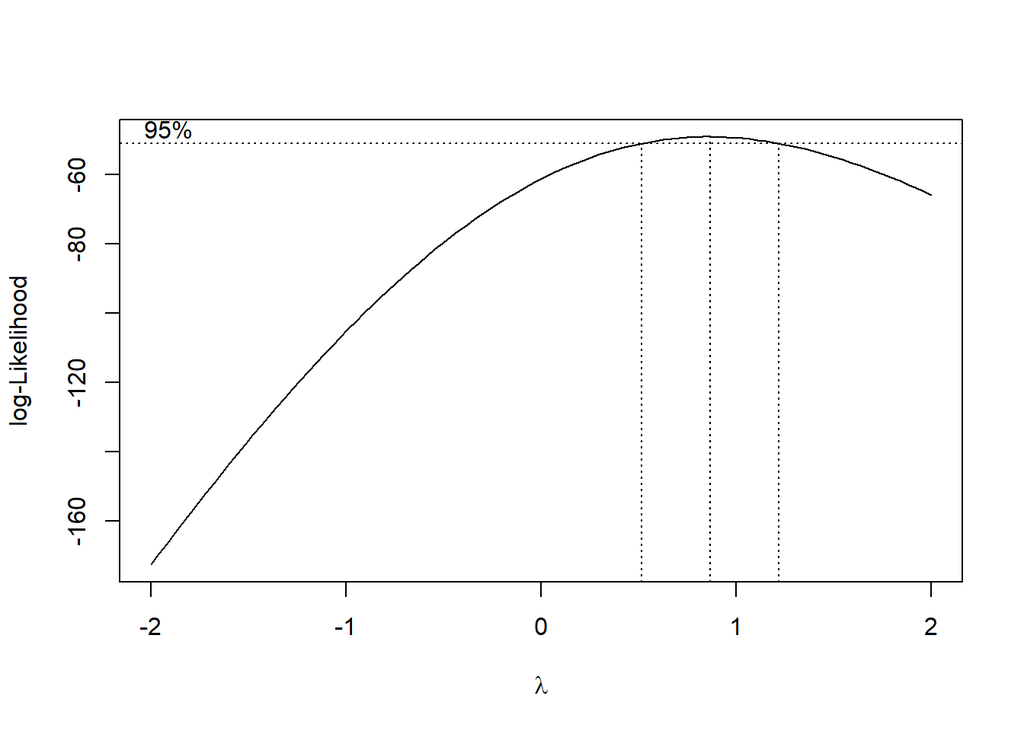

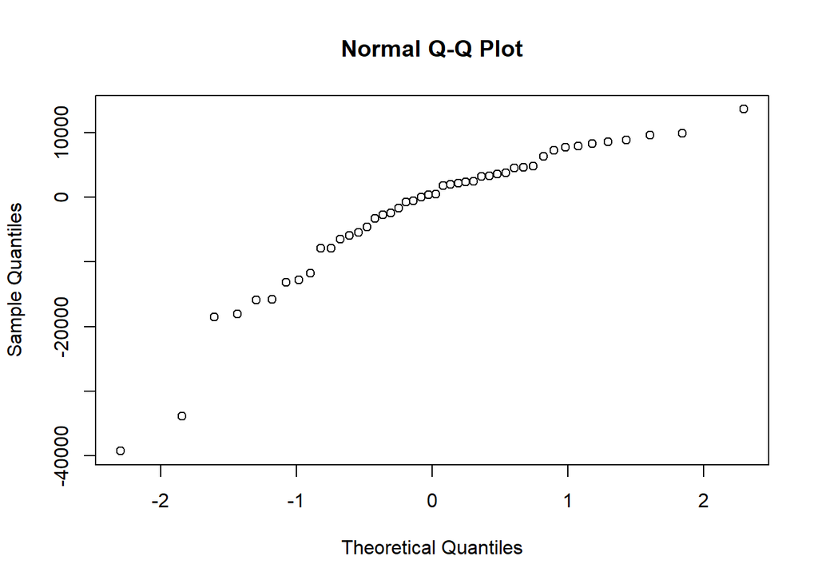

```r
lambda <- bc$x[which.max(bc$y)]
box_cox_model <- lmrob(((Farming^lambda-1)/lambda) ~ Population, data = counties_data_no_capital)

qqnorm(box_cox_model$residuals)
```

```r
#Huber regression
box_cox_model <- lmrob(Farming ~ Population, data = counties_data_no_capital)
summary(box_cox_model)
```

```
##
## Call:
## lmrob(formula = Farming ~ Population, data = counties_data_no_capital)
##  \--> method = "MM"
## Residuals:
##     Min      1Q  Median      3Q     Max
## -175556  -32191    1443   20609   64752
##
## Coefficients:
##                Estimate  Std. Error t value         Pr(>|t|)
## (Intercept)  3222.66126 11317.84186   0.285            0.777
## Population      0.15519     0.01578   9.835 0.00000000000111 ***
## ---
## Signif. codes:  0 '***' 0.001 '**' 0.01 '*' 0.05 '.' 0.1 ' ' 1
##
## Robust residual standard error: 33830
## Multiple R-squared:  0.7623, Adjusted R-squared:  0.7569
## Convergence in 15 IRWLS iterations
##
## Robustness weights:
##  2 observations c(1,22) are outliers with |weight| = 0 ( < 0.0022);
##  3 weights are ~= 1. The remaining 41 ones are summarized as
##    Min. 1st Qu.  Median    Mean 3rd Qu.    Max.
##  0.5052  0.8604  0.9367  0.8874  0.9861  0.9977
## Algorithmic parameters:
##        tuning.chi                bb        tuning.psi        refine.tol
##      1.5476400000      0.5000000000      4.6850610000      0.0000001000
##           rel.tol         scale.tol         solve.tol          zero.tol
##      0.0000001000      0.0000000001      0.0000001000      0.0000000001
##       eps.outlier             eps.x warn.limit.reject warn.limit.meanrw
##      0.0021739130      0.0000043707      0.5000000000      0.5000000000
##      nResample         max.it       best.r.s       k.fast.s          k.max
##            500             50              2              1            200
##    maxit.scale      trace.lev            mts     compute.rd fast.s.large.n
##            200              0           1000              0           2000
##                   psi           subsampling                   cov
##            "bisquare"         "nonsingular"         ".vcov.avar1"
## compute.outlier.stats
##                  "SM"
## seed : int(0)
```

```r
#Assumption 3.1: Normality of residuals
shapiro.test(box_cox_model$residuals)
```

```
##
##  Shapiro-Wilk normality test
##
## data:  box_cox_model$residuals
## W = 0.88047, p-value = 0.0002115
```

```r
##Assumption not met

#Assumption 3.2: Linearity
raintest(box_cox_model)
```

```
##
##  Rainbow test
##
## data:  box_cox_model
## Rain = 1.7883, df1 = 23, df2 = 21, p-value = 0.0926
```

```r
#Assumption met

#Assumption 3.3: Homoscedasticity
bptest(box_cox_model)
```

```
##
##  studentized Breusch-Pagan test
##
## data:  box_cox_model
## BP = 6.2772, df = 1, p-value = 0.01223
```

```r
#Assumption not met

#Furthermore, robust regression is not suitable for less than 100 observations
```

### **Hypothesis** 2: Linear regression

```r
##H2: Is there a positive correlation between Tea and Coffee production?
cor(counties_data_no_capital$Tea, counties_data_no_capital$Coffee, use = "pairwise.complete.obs")
```

```
## [1] 0.4166591
```

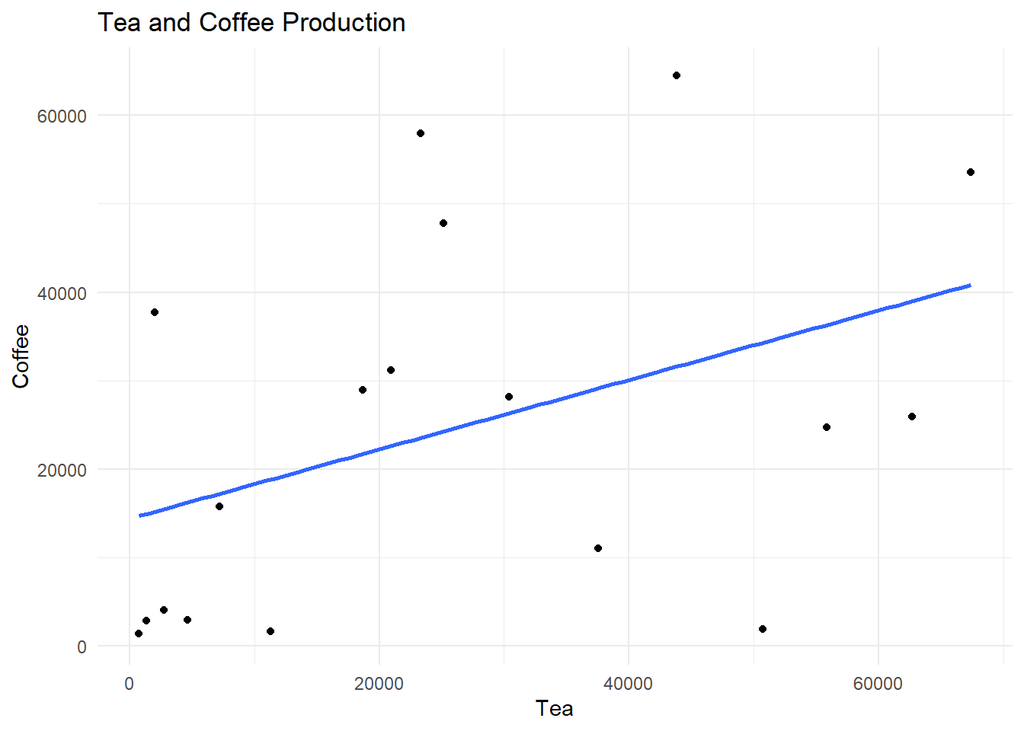

```r
counties_data_no_capital |>
  ggplot(aes(x = Tea, y = Coffee)) +
  geom_point() +
  geom_smooth(method = "lm", se = FALSE) +
  labs(
    title = "Tea and Coffee Production",
    x = "Tea",
    y = "Coffee"
  ) +
  theme_minimal()
```

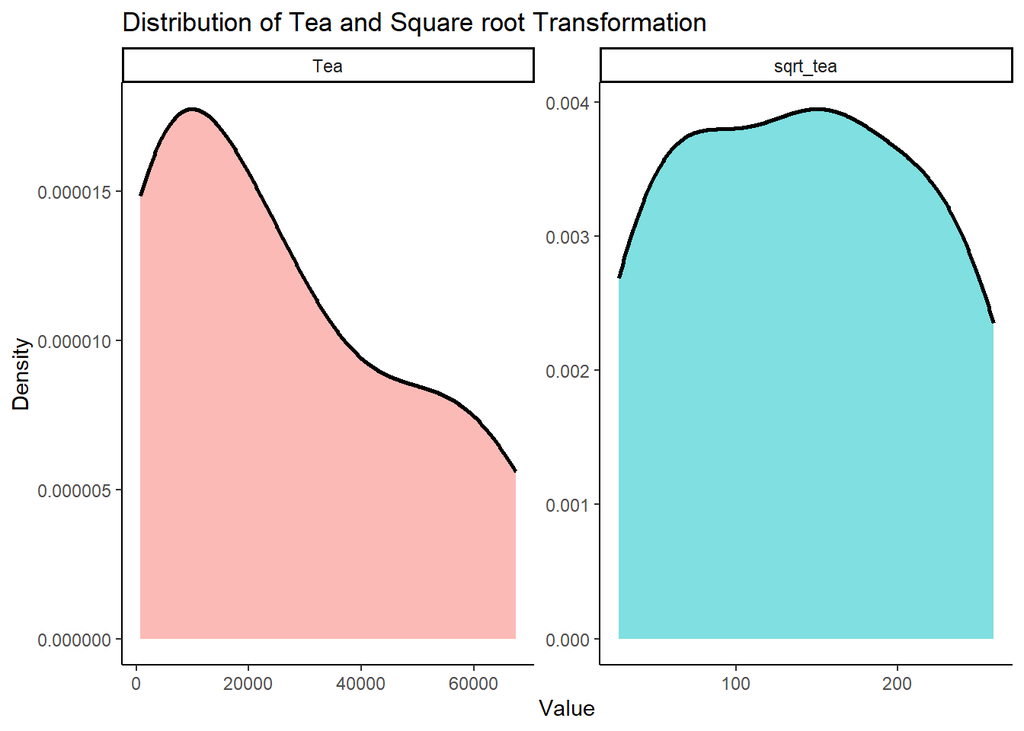

```r
#A square root transformation was done to make the data more normally distributed.
counties_data_no_capital_sqrt = counties_data_no_capital |>
  mutate(sqrt_tea = sqrt(Tea),
         sqrt_coffee = sqrt(Coffee))



counties_data_no_capital_sqrt |>
  pivot_longer(cols = c(Tea, sqrt_tea), names_to = "Variable", values_to = "Value") |>
  mutate(Variable = factor(Variable, levels = c("Tea", "sqrt_tea"))) |>
  ggplot(aes(x = Value, fill = Variable)) +
  geom_density(alpha = 0.5, color = "black", size = 1) +
  facet_wrap(~Variable, scales = "free") +
  labs(title = "Distribution of Tea and Square root Transformation",
       x = "Value",
       y = "Density") +
  theme_classic() +
  theme(legend.position = "none")
```

```r
tea_model <- lm(sqrt_tea ~ sqrt_coffee, data = counties_data_no_capital_sqrt)

#Assumption 4.1: Normality
shapiro.test(counties_data_no_capital_sqrt$sqrt_tea)
```

```
##
##  Shapiro-Wilk normality test
##
## data:  counties_data_no_capital_sqrt$sqrt_tea
## W = 0.94668, p-value = 0.3465
```

```r
##Normality met

#Assumption 4.2: Linearity
raintest(tea_model)
```

```
##
##  Rainbow test
##
## data:  tea_model
## Rain = 0.94536, df1 = 9, df2 = 7, p-value = 0.5425
```

```r
##Linearity met

#Assumption 4.3: Homoscedasticity
bptest(tea_model)
```

```
##
##  studentized Breusch-Pagan test
##
## data:  tea_model
## BP = 0.3504, df = 1, p-value = 0.5539
```

```r
##Homoscedasticity met

#Assumption 4.4: Normality of residuals
shapiro.test(tea_model$residuals)
```

```
##
##  Shapiro-Wilk normality test
##
## data:  tea_model$residuals
## W = 0.95603, p-value = 0.5273
```

```r
##Normality of residuals met

#All assumptions met
```

## Hypothesis 2: **Results**

```r
apa_table <- apa.reg.table(tea_model)
stats.table <- as.data.frame(summary(tea_model)$coefficients)
CI <- confint(tea_model)
stats.table <- cbind(row.names(stats.table), stats.table, CI)
names(stats.table) <- c("Variable", "Estimate", "Std. Error", "t-value", "p", "CI_lower", "CI_upper")
nice_table(stats.table, title = "Model coefficients", highlight = .05, note = c("CI = Confidence Interval", "* p < 0.05"))
```

| Model coefficients Variable | Model coefficients Estimate | Model coefficients Std. Error | Model coefficients t-value | Model coefficients p | Model coefficients 95% CI |
| --- | --- | --- | --- | --- | --- |
| (Intercept) | 71.71 | 35.06 | 2.05 | .058 | [-2.62, 146.04] |
| sqrt_coffee | 0.51 | 0.22 | 2.28 | .037* | [0.04, 0.98] |

Note. CI = Confidence Interval  
* p < 0.05

```r
model_fit <- broom::glance(tea_model)
model_fit <- model_fit[, !(names(model_fit) %in% c("AIC", "BIC", "logLik", "nobs"))]
names(model_fit) <- gsub("sigma", "SD", names(model_fit), ignore.case = TRUE)
model_fit = model_fit |>
  mutate(
    SD = as.numeric(SD),
    SD = round(SD, digits = 3)
  )
fit_table <- cbind(row.names(model_fit), model_fit)
nice_table(model_fit, title = "Model fit", note = c("* p < 0.05", "SD = Standard Deviation"))
```

| Model fit r.squared | Model fit adj.r.squared | Model fit SD | Model fit statistic | Model fit p | Model fit df | Model fit deviance | Model fit df.residual |
| --- | --- | --- | --- | --- | --- | --- | --- |
| 0.24 | 0.20 | 69.23 | 5.19 | .037* | 1 | 76,695.65 | 16 |

Note. * p < 0.05  
SD = Standard Deviation

#### There is a statistically significant moderate positive correlation between Tea and Coffee production, however there is a very limited sample size, because few counties have data abouth both Tea and Coffee production. The large confidence interval aligns with this conclusion. Coffee production explains 20% of the variance in Tea production.